# **Analyzing Video Game Sales - Tom Dai**

Video games have become a popular form of entertainment and a significant industry in recent years. According to industry reports, the global video game market was valued at over $175 billion in 2020, and it is projected to continue growing in the coming years.

The creation of video games have become more and more complex as both technolgy advances and consumer tastes change. This means that the development costs for one game is often atronomical, and today modern videogames often require millions of dollar funding similar to hollywood budgets to get off the ground. However every game developed is a moonshot worth millions of dollars that could be wasted if there are no sales to prop it up.

This risk however is very worthwhile. Currently, the video game industry is large than both the music and movie industry combined, while having immense potential for growth. It is estimated that there are around 2 billion people in the world who buy and play video games. That is nearly 1 out of every 4 people. Video games being a software product makes it very easy to scale and ship world wide, compared to other industries which may be stricted to their regions due to industry contraints.

Analyzing video game sales data can provide valuable insights into what drives people to buying a certain video game. By analzying infomation about sales from video games, game developers and publishers can make informed decisions about what makes a game attractive for their development of their titles, ensuring that each moonshot they make will hopefully hit its target.

So let us determine what exactly makes a video game sell well.

# 1. **Data Collection**

To start with, we need to collect our data about video game sales. We are using a website called [vgcharz](https://www.vgchartz.com/) that has data on thousands of video game titles, their sales, their ratings, etc. VGChartz is a website that provides video game sales data and related information to video game industry professionals, analysts, and enthusiasts. They collect data from various sources, including publishers, retailers, and consumers, and provide information on game sales, release dates, platforms, genres, and more. VGChartz is often used by video game industry professionals to track market trends, analyze sales data, and make business decisions.

Due to the large volume of data needed to be scraped, I am using a python framework called Scrapy to scrape information from the website, and write it in as CSV file. This program was ran seperately to save resources and time, but the most meaningful part of the implementation is shown below. Scrapy allows for minimal code writing, saves resources, and pretty much allows one to basically run it in the background. All one has to do is write the rules and Scrapy will use a 'spider' that will asychronously gather the data you want. For more infomation about using Scrapy for yourself visit: https://docs.scrapy.org/en/latest/intro/overview.html

```python
from scrapy import Request, Spider


def strip(value):
    return value.strip() if isinstance(value, str) else value


class GameStatisticsSpider(Spider):
    name = "game_statistics"

    def __init__(self, name=None, **kwargs):
        super().__init__(name, **kwargs)
        self.pages = int(kwargs.get("pages", 10))

    #aschronously sends a get request
    def start_requests(self):
        for i in range(1, self.pages + 1):
            yield Request(f"https://www.vgchartz.com/games/games.php?page={i}&order=Sales&ownership=Both&direction=DESC&showtotalsales=1&shownasales=1&showpalsales=1&showjapansales=1&showothersales=1&showpublisher=1&showdeveloper=1&showreleasedate=1&showlastupdate=1&showvgchartzscore=1&showcriticscore=1&showuserscore=1&showshipped=1")

    #parses out the html response into the data we want
    def parse(self, response):
            for game in response.xpath(".//div[@id='generalBody']/table/tr"):
                title = self.get_title(game)
                if title is None:
                    continue  # None-titles are column headers or the footer row

                yield {
                    "pos": strip(game.xpath(".//td[1]/text()").get()),
                    "title": title,
                    "platform": strip(game.xpath(".//td[4]/img/@alt").get()),
                    "publisher": strip(game.xpath(".//td[5]/text()").get()),
                    "developer": strip(game.xpath(".//td[6]/text()").get()),
                    "vgchartz_score": strip(game.xpath(".//td[7]/text()").get()),
                    "critic_score": strip(game.xpath(".//td[8]/text()").get()),
                    "user_score": strip(game.xpath(".//td[9]/text()").get()),
                    "total_shipped": strip(game.xpath(".//td[10]/text()").get()),
                    "total_sales": strip(game.xpath(".//td[11]/text()").get()),
                    "na_sales": strip(game.xpath(".//td[12]/text()").get()),
                    "pal_sales": strip(game.xpath(".//td[13]/text()").get()),
                    "japan_sales": strip(game.xpath(".//td[14]/text()").get()),
                    "other_sales": strip(game.xpath(".//td[15]/text()").get()),
                    "release_date": strip(game.xpath(".//td[16]/text()").get()),
                    "last_update": strip(game.xpath(".//td[17]/text()").get()),
                }

  #returns the title of our game
    def get_title(self, game):
        title = game.xpath(".//td[3]/a/text()").get()
        return title.strip() if isinstance(title, str) else title
```

# 2. **Data Wrangling and Inital Visualizations/Analysis**

Now that we have scrapped our data, we now need to analyze it to find any patterns or relations that could potentially determine a game's price.

This is our inital dataframe from our CSV file

```python
import pandas as pd
import matplotlib.pyplot as plt
import numpy as np
df = pd.read_csv('Video_Games.csv')
# display the first 10 rows of the dataframe
df
```

|  | Name | Platform | Year_of_Release | Genre | Publisher | NA_Sales | EU_Sales | JP_Sales | Other_Sales | Global_Sales | Critic_Score | Critic_Count | User_Score | User_Count | Developer | Rating |
| --- | --- | --- | --- | --- | --- | --- | --- | --- | --- | --- | --- | --- | --- | --- | --- | --- |
| 0 | Wii Sports | Wii | 2006.0 | Sports | Nintendo | 41.36 | 28.96 | 3.77 | 8.45 | 82.53 | 76.0 | 51.0 | 8 | 322.0 | Nintendo | E |
| 1 | Super Mario Bros. | NES | 1985.0 | Platform | Nintendo | 29.08 | 3.58 | 6.81 | 0.77 | 40.24 | NaN | NaN | NaN | NaN | NaN | NaN |
| 2 | Mario Kart Wii | Wii | 2008.0 | Racing | Nintendo | 15.68 | 12.76 | 3.79 | 3.29 | 35.52 | 82.0 | 73.0 | 8.3 | 709.0 | Nintendo | E |
| 3 | Wii Sports Resort | Wii | 2009.0 | Sports | Nintendo | 15.61 | 10.93 | 3.28 | 2.95 | 32.77 | 80.0 | 73.0 | 8 | 192.0 | Nintendo | E |
| 4 | Pokemon Red/Pokemon Blue | GB | 1996.0 | Role-Playing | Nintendo | 11.27 | 8.89 | 10.22 | 1.00 | 31.37 | NaN | NaN | NaN | NaN | NaN | NaN |
| ... | ... | ... | ... | ... | ... | ... | ... | ... | ... | ... | ... | ... | ... | ... | ... | ... |
| 16714 | Samurai Warriors: Sanada Maru | PS3 | 2016.0 | Action | Tecmo Koei | 0.00 | 0.00 | 0.01 | 0.00 | 0.01 | NaN | NaN | NaN | NaN | NaN | NaN |
| 16715 | LMA Manager 2007 | X360 | 2006.0 | Sports | Codemasters | 0.00 | 0.01 | 0.00 | 0.00 | 0.01 | NaN | NaN | NaN | NaN | NaN | NaN |
| 16716 | Haitaka no Psychedelica | PSV | 2016.0 | Adventure | Idea Factory | 0.00 | 0.00 | 0.01 | 0.00 | 0.01 | NaN | NaN | NaN | NaN | NaN | NaN |
| 16717 | Spirits & Spells | GBA | 2003.0 | Platform | Wanadoo | 0.01 | 0.00 | 0.00 | 0.00 | 0.01 | NaN | NaN | NaN | NaN | NaN | NaN |
| 16718 | Winning Post 8 2016 | PSV | 2016.0 | Simulation | Tecmo Koei | 0.00 | 0.00 | 0.01 | 0.00 | 0.01 | NaN | NaN | NaN | NaN | NaN | NaN |

16719 rows × 16 columns

As you can see, some of the rows have missing values. We have two options to deal with this problem. One option is that we can use the data that we do have and train a model so that we can predict a value to fill in for our missing data. The other option is that we ignore the data that has the missing values and drop it entirely in our analysis.

We will be going with the second option. We want to determine what drives video game sales, and missing data will not help us reach that conclusion.

```python
df = df.replace('tbd', np.nan)
dropped = df.dropna()
dropped
```

|  | Name | Platform | Year_of_Release | Genre | Publisher | NA_Sales | EU_Sales | JP_Sales | Other_Sales | Global_Sales | Critic_Score | Critic_Count | User_Score | User_Count | Developer | Rating |
| --- | --- | --- | --- | --- | --- | --- | --- | --- | --- | --- | --- | --- | --- | --- | --- | --- |
| 0 | Wii Sports | Wii | 2006.0 | Sports | Nintendo | 41.36 | 28.96 | 3.77 | 8.45 | 82.53 | 76.0 | 51.0 | 8 | 322.0 | Nintendo | E |
| 2 | Mario Kart Wii | Wii | 2008.0 | Racing | Nintendo | 15.68 | 12.76 | 3.79 | 3.29 | 35.52 | 82.0 | 73.0 | 8.3 | 709.0 | Nintendo | E |
| 3 | Wii Sports Resort | Wii | 2009.0 | Sports | Nintendo | 15.61 | 10.93 | 3.28 | 2.95 | 32.77 | 80.0 | 73.0 | 8 | 192.0 | Nintendo | E |
| 6 | New Super Mario Bros. | DS | 2006.0 | Platform | Nintendo | 11.28 | 9.14 | 6.50 | 2.88 | 29.80 | 89.0 | 65.0 | 8.5 | 431.0 | Nintendo | E |
| 7 | Wii Play | Wii | 2006.0 | Misc | Nintendo | 13.96 | 9.18 | 2.93 | 2.84 | 28.92 | 58.0 | 41.0 | 6.6 | 129.0 | Nintendo | E |
| ... | ... | ... | ... | ... | ... | ... | ... | ... | ... | ... | ... | ... | ... | ... | ... | ... |
| 16667 | E.T. The Extra-Terrestrial | GBA | 2001.0 | Action | NewKidCo | 0.01 | 0.00 | 0.00 | 0.00 | 0.01 | 46.0 | 4.0 | 2.4 | 21.0 | Fluid Studios | E |
| 16677 | Mortal Kombat: Deadly Alliance | GBA | 2002.0 | Fighting | Midway Games | 0.01 | 0.00 | 0.00 | 0.00 | 0.01 | 81.0 | 12.0 | 8.8 | 9.0 | Criterion Games | M |
| 16696 | Metal Gear Solid V: Ground Zeroes | PC | 2014.0 | Action | Konami Digital Entertainment | 0.00 | 0.01 | 0.00 | 0.00 | 0.01 | 80.0 | 20.0 | 7.6 | 412.0 | Kojima Productions | M |
| 16700 | Breach | PC | 2011.0 | Shooter | Destineer | 0.01 | 0.00 | 0.00 | 0.00 | 0.01 | 61.0 | 12.0 | 5.8 | 43.0 | Atomic Games | T |
| 16706 | STORM: Frontline Nation | PC | 2011.0 | Strategy | Unknown | 0.00 | 0.01 | 0.00 | 0.00 | 0.01 | 60.0 | 12.0 | 7.2 | 13.0 | SimBin | E10+ |

6825 rows × 16 columns

Now what we will do is explore the data to see if we notice any kind of relationship between the columns.

We can use the seaborn library to give us statstics about our dataframe.

```python
import seaborn as sns
# get summary statistics of the numerical columns
print(dropped.describe())

# get the count of unique values in each column
print(dropped.nunique())

# get the correlation matrix of the numerical columns
corr = dropped.corr()
print(corr)
```

```
       Year_of_Release     NA_Sales     EU_Sales     JP_Sales  Other_Sales  \
count      6825.000000  6825.000000  6825.000000  6825.000000  6825.000000
mean       2007.436777     0.394484     0.236089     0.064158     0.082677
std           4.211248     0.967385     0.687330     0.287570     0.269871
min        1985.000000     0.000000     0.000000     0.000000     0.000000
25%        2004.000000     0.060000     0.020000     0.000000     0.010000
50%        2007.000000     0.150000     0.060000     0.000000     0.020000
75%        2011.000000     0.390000     0.210000     0.010000     0.070000
max        2016.000000    41.360000    28.960000     6.500000    10.570000

       Global_Sales  Critic_Score  Critic_Count    User_Count
count   6825.000000   6825.000000   6825.000000   6825.000000
mean       0.777590     70.272088     28.931136    174.722344
std        1.963443     13.868572     19.224165    587.428538
min        0.010000     13.000000      3.000000      4.000000
25%        0.110000     62.000000     14.000000     11.000000
50%        0.290000     72.000000     25.000000     27.000000
75%        0.750000     80.000000     39.000000     89.000000
max       82.530000     98.000000    113.000000  10665.000000
Name               4377
Platform             17
Year_of_Release      25
Genre                12
Publisher           262
NA_Sales            351
EU_Sales            273
JP_Sales            157
Other_Sales         144
Global_Sales        536
Critic_Score         81
Critic_Count        106
User_Score           89
User_Count          875
Developer          1289
Rating                7
dtype: int64
                 Year_of_Release  NA_Sales  EU_Sales  JP_Sales  Other_Sales  \
Year_of_Release         1.000000 -0.016239  0.041346 -0.038443     0.042315
NA_Sales               -0.016239  1.000000  0.841808  0.468607     0.726757
EU_Sales                0.041346  0.841808  1.000000  0.519929     0.716330
JP_Sales               -0.038443  0.468607  0.519929  1.000000     0.394823
Other_Sales             0.042315  0.726757  0.716330  0.394823     1.000000
Global_Sales            0.006661  0.955793  0.939313  0.613546     0.804028
Critic_Score           -0.007661  0.233580  0.213102  0.147314     0.191509
Critic_Count            0.203336  0.283917  0.265740  0.168299     0.239513
User_Count              0.199348  0.246208  0.283504  0.072773     0.240085

                 Global_Sales  Critic_Score  Critic_Count  User_Count
Year_of_Release      0.006661     -0.007661      0.203336    0.199348
NA_Sales             0.955793      0.233580      0.283917    0.246208
EU_Sales             0.939313      0.213102      0.265740    0.283504
JP_Sales             0.613546      0.147314      0.168299    0.072773
Other_Sales          0.804028      0.191509      0.239513    0.240085
Global_Sales         1.000000      0.237556      0.290397    0.264151
Critic_Score         0.237556      1.000000      0.396478    0.265639
Critic_Count         0.290397      0.396478      1.000000    0.365603
User_Count           0.264151      0.265639      0.365603    1.000000
```

This gives us some points of interest on what kind of relationships between the columns we should be on the look out for.

Next, let's see how many sales where on a certain platform (hardware console). We are going to use the mathplt libary to create a bargraph using the columns from our dataframe. In this sceneario we are plotting the platform of each video game against their global sales.

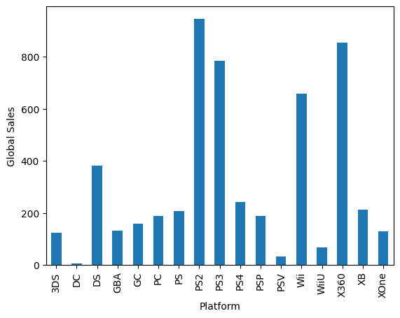

```python
# group the data by platform and sum the global sales
sales_by_platform = dropped.groupby('Platform')['Global_Sales'].sum()

# plot a bar chart of the total global sales by platform
sales_by_platform.plot(kind='bar')
plt.xlabel('Platform')
plt.ylabel('Global Sales')
plt.show()
```

This visualzation makes it easy to see which platforms are larger than the other, however if we want to see the total share it takes up in the total global sales of games, then we need to plot a pie chart.

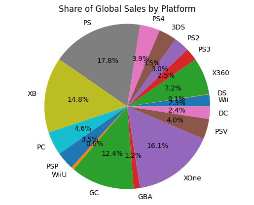

```python
# group the data by platform and sum the global sales
sales_by_platform = dropped.groupby('Platform')['Global_Sales'].sum()

# create a pie chart of the share of global sales by platform
plt.pie(sales_by_platform.values, labels=dropped['Platform'].unique(), autopct='%1.1f%%')
plt.title('Share of Global Sales by Platform')
plt.axis('equal')
plt.show()
```

Now let us analyze what platforms each region is comprised of.

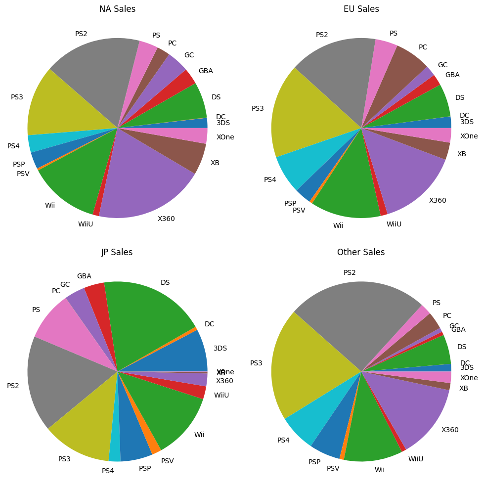

```python
# group the data by platform and sum the sales in each region
sales_by_platform_region = dropped.groupby('Platform')[['NA_Sales', 'EU_Sales', 'JP_Sales', 'Other_Sales']].sum()

# create a figure with 2 rows and 2 columns
fig, axs = plt.subplots(nrows=2, ncols=2, figsize=(10, 10))

# plot the total sales for each platform in each region
axs[0, 0].pie(sales_by_platform_region['NA_Sales'], labels=sales_by_platform_region.index)
axs[0, 0].set_title('NA Sales')
axs[0, 1].pie(sales_by_platform_region['EU_Sales'], labels=sales_by_platform_region.index)
axs[0, 1].set_title('EU Sales')
axs[1, 0].pie(sales_by_platform_region['JP_Sales'], labels=sales_by_platform_region.index)
axs[1, 0].set_title('JP Sales')
axs[1, 1].pie(sales_by_platform_region['Other_Sales'], labels=sales_by_platform_region.index)
axs[1, 1].set_title('Other Sales')

# adjust the spacing between subplots
fig.tight_layout()

# show the plot
plt.show()
```

It seems across the board that the PS2 and PS3 have somewhat of a larger slice of the pie, but in Japan it seems that the Xbox, Xbox360 and the XboxOne are pretty much not getting any sales at all.

Let us determine if the ratings affect if a game sells well or not. In the seaborn library, we will be using a joinplot. It is a plot which combines scatter plot and histogram plots to give us the information about the bivariate distribution of two variables along with the univariate distribution of each variable. It can also include a regression line, a kernel density estimation, and a Pearson correlation coefficient. This type of plot is useful to explore the relationship between two variables, especially in large datasets.

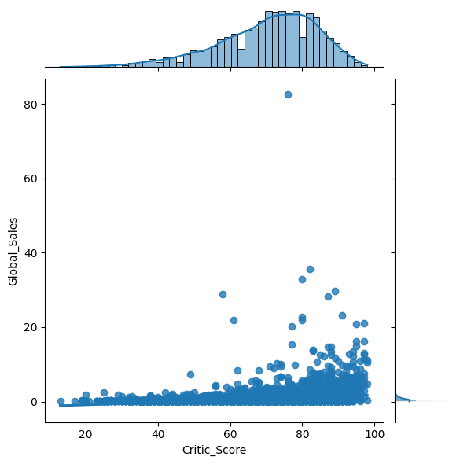

```python
sns.jointplot(data=dropped, x='Critic_Score', y='Global_Sales', kind='reg')
plt.show()
```

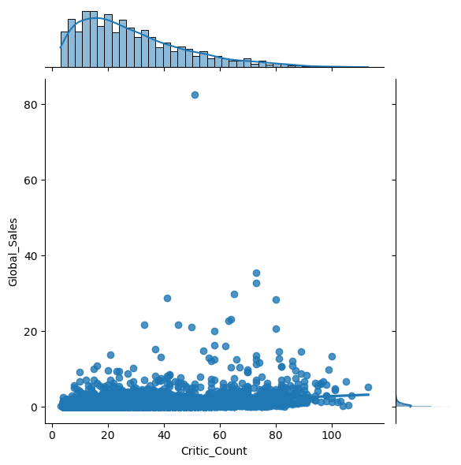

```python
sns.jointplot(data=dropped, x='Critic_Count', y='Global_Sales', kind='reg')
plt.show()
```

Now let us determine if publishers determine video game sales. We will just be using barplots and only take the top 10 of publishers to see if any of them have changed.

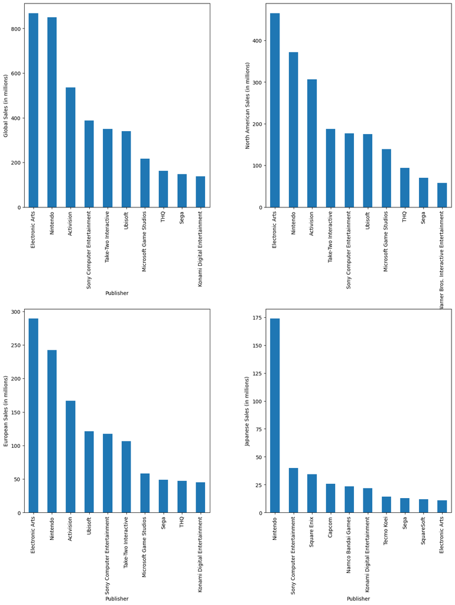

```python
# create a figure with 2 rows and 2 columns of subplots
fig, axs = plt.subplots(nrows=2, ncols=2, figsize=(15,18))

# plot the top 10 publishers by Global Sales
top_publishers = dropped.groupby('Publisher')['Global_Sales'].sum().nlargest(10)
top_publishers.plot(kind='bar', ax=axs[0, 0])
axs[0, 0].set_xlabel('Publisher')
axs[0, 0].set_ylabel('Global Sales (in millions)')

# plot the top 10 publishers for North American Sales
top_publishers = dropped.groupby('Publisher')['NA_Sales'].sum().nlargest(10)
top_publishers.plot(kind='bar', ax=axs[0, 1])
axs[0, 1].set_xlabel('Publisher')
axs[0, 1].set_ylabel('North American Sales (in millions)')

# plot the top 10 publishers for European Sales
top_publishers = dropped.groupby('Publisher')['EU_Sales'].sum().nlargest(10)
top_publishers.plot(kind='bar', ax=axs[1, 0])
axs[1, 0].set_xlabel('Publisher')
axs[1, 0].set_ylabel('European Sales (in millions)')

# plot the top 10 publishers for Japanese Sales
top_publishers = dropped.groupby('Publisher')['JP_Sales'].sum().nlargest(10)
top_publishers.plot(kind='bar', ax=axs[1, 1])
axs[1, 1].set_xlabel('Publisher')
axs[1, 1].set_ylabel('Japanese Sales (in millions)')

# adjust the spacing between subplots
plt.subplots_adjust(wspace=0.3, hspace=0.5)

# show the plot
plt.show()
```

Next, lets look at genres of video games which is the type of gameplay a video game will have. For example shooting games will have guns where you shoot stuff. Conversly, a strategy game may not have any shooting elements.

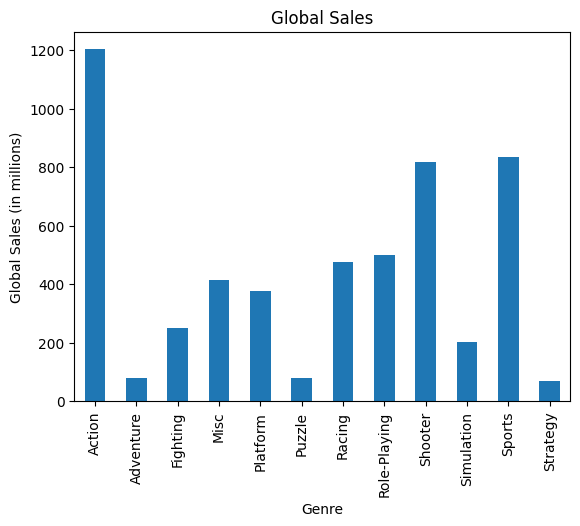

```python
# Visualize sales by genre
# plot each genre by japn europe and then na
genres = dropped.groupby('Genre')['Global_Sales'].sum()
genres.plot(kind='bar')
plt.title("Global Sales")
plt.xlabel('Genre')
plt.ylabel('Global Sales (in millions)')
plt.show()
```

Now let's look at the same plot, but grouped by their respective regions.

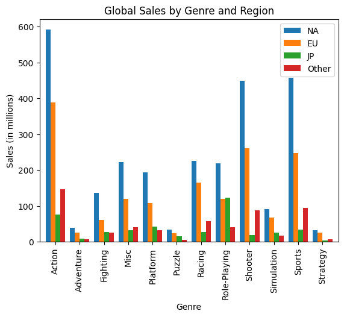

```python
# group the data by genre and sum the sales by region
sales_by_genre = dropped.groupby('Genre')[['NA_Sales', 'EU_Sales', 'JP_Sales', 'Other_Sales']].sum()

# plot a grouped bar chart of sales by genre and region
ax = sales_by_genre.plot(kind='bar', width=0.8)

# set the title and axis labels
ax.set_title('Global Sales by Genre and Region')
ax.set_xlabel('Genre')
ax.set_ylabel('Sales (in millions)')

# set the x-tick labels at 0.4, 1.4, 2.4, and 3.4
ax.set_xticks(np.arange(len(sales_by_genre)))
ax.set_xticklabels(sales_by_genre.index)

# add the legend
ax.legend(['NA', 'EU', 'JP', 'Other'])

# show the plot
plt.show()
```

Once again, we can better visualize this difference of the sales of genres for each region with a pie chart.

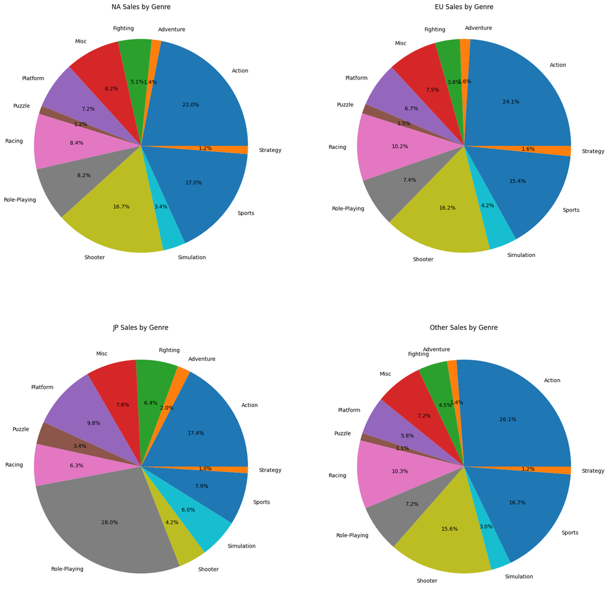

```python
# group by genre and sum the sales for each region
na_sales_by_genre = dropped.groupby('Genre')['NA_Sales'].sum()
eu_sales_by_genre = dropped.groupby('Genre')['EU_Sales'].sum()
jp_sales_by_genre = dropped.groupby('Genre')['JP_Sales'].sum()
other_sales_by_genre = dropped.groupby('Genre')['Other_Sales'].sum()

# create a list of the sales by genre for each region
sales_by_genre = [na_sales_by_genre, eu_sales_by_genre, jp_sales_by_genre, other_sales_by_genre]

# create a list of labels for the regions
region_labels = ['NA', 'EU', 'JP', 'Other']

# set the figure size
plt.figure(figsize=(20, 20))

# create a pie chart for each region
for i in range(len(sales_by_genre)):
    plt.subplot(2, 2, i+1)
    plt.pie(sales_by_genre[i], labels=sales_by_genre[i].index, autopct='%1.1f%%')
    plt.title(f'{region_labels[i]} Sales by Genre')

plt.show()
```

As you can see, each region has very similar composition of genres with the exception of Japan, which seems to value Role-Playing and Platformer games a lot more than the rest of the world.

Let's see how each genre trends over time and see if the Year of release matters for sales.

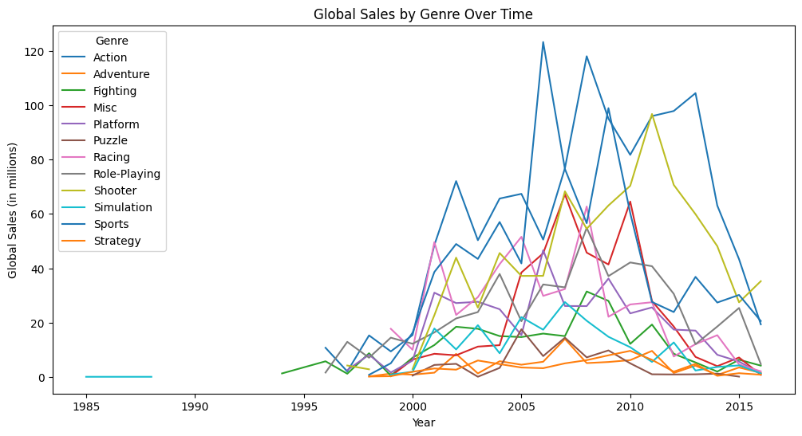

```python
# group the data by genre and year and calculate the sum of global sales for each group
sales_by_genre_and_year = dropped.groupby(['Genre', 'Year_of_Release'])['Global_Sales'].sum()

# create a pivot table to make the data easier to plot
sales_by_genre_and_year = sales_by_genre_and_year.unstack('Genre')

# plot the data as a line chart
sales_by_genre_and_year.plot(kind='line', figsize=(12, 6))

# set the title, x-axis label, and y-axis label
plt.title('Global Sales by Genre Over Time')
plt.xlabel('Year')
plt.ylabel('Global Sales (in millions)')

# display the chart
plt.show()
```

It looks like that over time, genre popularity does not stay stagnant and often moves with the market. This means that time is very important in this industry, and waiting too long means that a genre might be dead within a few years.

Let us see how the genre's perform in each region

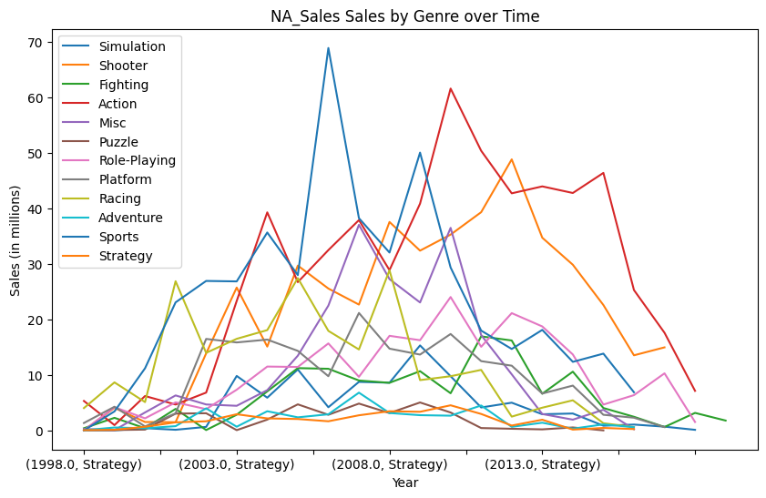

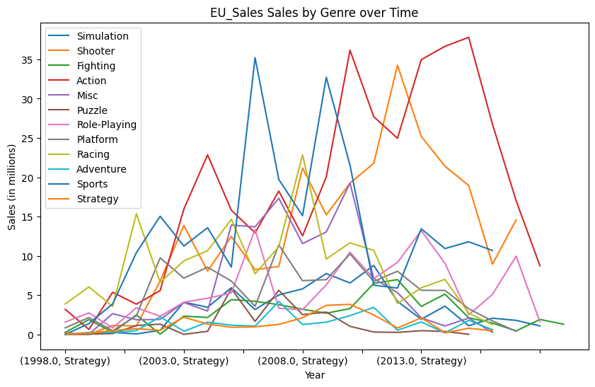

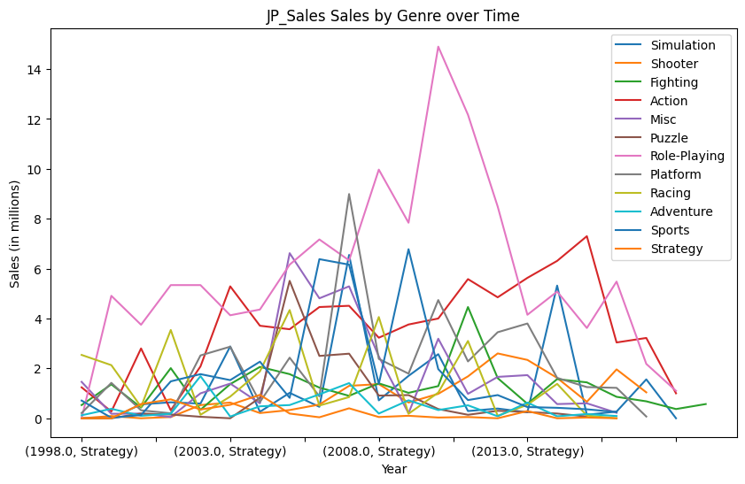

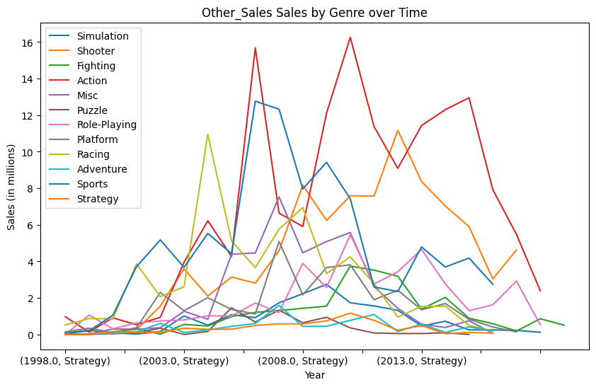

```python
# create a pivot table to get the total sales of each genre in each year for each region
sales_by_genre_year_region = pd.pivot_table(dropped, values=['NA_Sales', 'EU_Sales', 'JP_Sales', 'Other_Sales'], index=['Year_of_Release', 'Genre'], aggfunc=np.sum)

# create a list of unique regions
regions = ['NA_Sales', 'EU_Sales', 'JP_Sales', 'Other_Sales']

# create a line plot for each region with each genre as a line
for region in regions:
    fig, ax = plt.subplots(figsize=(10, 6))
    for genre in sales_by_genre_year_region.index.get_level_values('Genre').unique():
        sales_by_genre_region = sales_by_genre_year_region.loc[(slice(None), genre), region]
        sales_by_genre_region.plot(kind='line', ax=ax, label=genre)

    # set the title and axis labels
    ax.set_title(f"{region} Sales by Genre over Time")
    ax.set_xlabel('Year')
    ax.set_ylabel('Sales (in millions)')

    # add a legend
    ax.legend(loc='best')

    plt.show()
```

Once again, it seems that Japan has very different preferences in genres compared to the rest of the world, emphesizing how much region matters to overall video game sales, also showing that the genre may matter when it comes to sales.

Finally let us see if there is a relationship between developers and sales. We will be measuring the number of games developed by a developer and plot it against their total sales, and see if there is some sort of linear relationship.

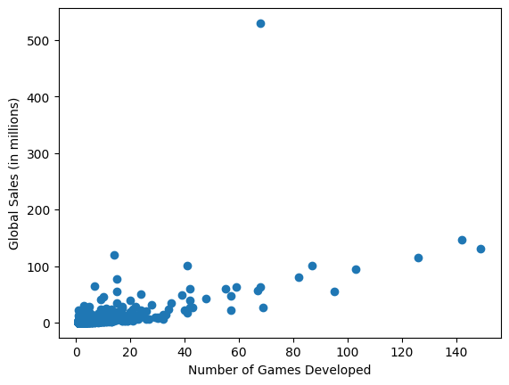

```python
# group the data by developer and sum the global sales
sales_by_developer = dropped.groupby('Developer')['Global_Sales'].sum()

# create a scatter plot of global sales vs number of games developed
plt.scatter(dropped.groupby('Developer')['Global_Sales'].count(), sales_by_developer)
plt.xlabel('Number of Games Developed')
plt.ylabel('Global Sales (in millions)')
plt.show()
```

The plot suggests that developers do contribute to the sales of video games.

# **3. Analysis with Linear Regression and Hypothesis Testing**

But first let us double check to see if our factors have a strong or weak relationship with sales.

To determine this, we can use linear regression and calculate the R-value, which measures how strong a relationship is between two variables. We will use hypothesis testing to see whether or not that result we get is significant. Our null hypothesis is an assumption about the data we assume to be true unless proven otherwise. In this case our null hypothesis is that we assume community interaction has no correlation with global sales. The alternative hypothesis is the assumption that the opposite is true. This is only true if our null hypothesis is rejected. In our case the AH is that community interaction and global sales are indeed correlated. To determine whether or not the null hypothesis should be rejected, we must calculate the p-value, which is a value that determine whether or not the null hypothesis is rejected.

To prove that community interaction is indeed related to sales, we will be using linear regression to do so. Using the scipy library, we can create a linear regression model that will do all the math and calulate our r value and p value for us! We will use the critic count and user count to represent community interaction.

```
Slope: 0.03
Intercept: -0.08
R-value: 0.29
P-value: 0.00
Standard Error: 0.00
Slope: 0.00
Intercept: 0.62
R-value: 0.26
P-value: 0.00
Standard Error: 0.00
```

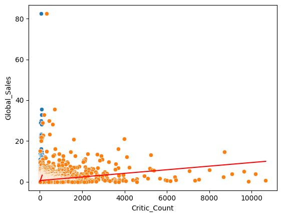

```python
from scipy import stats

# convert User_Score to a numerical data type
dropped['Critic_Count'] = pd.to_numeric(dropped['Critic_Count'], errors='coerce')

# drop rows with missing values
dropped = dropped.dropna(subset=['Critic_Count', 'Global_Sales'])

# create a scatter plot of global sales vs. Critic scores
sns.scatterplot(x='Critic_Count', y='Global_Sales', data=dropped)

# perform a linear regression
regression = stats.linregress(dropped['Critic_Count'], dropped['Global_Sales'])
slope = regression.slope
intercept = regression.intercept
rvalue = regression.rvalue
pvalue = regression.pvalue
stderr = regression.stderr

# plot the regression line
sns.lineplot(x=dropped['Critic_Count'], y=slope * dropped['Critic_Count'] + intercept, color='red')

# print the regression results
print(f"Slope: {slope:.2f}")
print(f"Intercept: {intercept:.2f}")
print(f"R-value: {rvalue:.2f}")
print(f"P-value: {pvalue:.2f}")
print(f"Standard Error: {stderr:.2f}")

# drop rows with missing values
dropped = dropped.dropna(subset=['User_Count', 'Global_Sales'])

# create a scatter plot of global sales vs. user scores
sns.scatterplot(x='User_Count', y='Global_Sales', data=dropped)

# perform a linear regression
regression = stats.linregress(dropped['User_Count'], dropped['Global_Sales'])
slope = regression.slope
intercept = regression.intercept
rvalue = regression.rvalue
pvalue = regression.pvalue
stderr = regression.stderr

# plot the regression line
sns.lineplot(x=dropped['User_Count'], y=slope * dropped['User_Count'] + intercept, color='red')

# print the regression results
print(f"Slope: {slope:.2f}")
print(f"Intercept: {intercept:.2f}")
print(f"R-value: {rvalue:.2f}")
print(f"P-value: {pvalue:.2f}")
print(f"Standard Error: {stderr:.2f}")
```

As you can see our p-value is 0, meaning we are able to reject the null hypothesis since it is lower than 0.05 which is our signifcance level. This means that interaction and sales are indeed correlated and have a relationship. The R-value of 0.29 suggests that the correlation is weak.

Next, let us create a linear regression model with the rest of our discrete factors, that is factors that are not numeric. In our case that is Devlopers, Publishers, Platform and Genre. We have shown that these discrete factors influence the sales of video games somewhat in part 2. With these terms added, we can improve how well our model fits and can predict the sales of a video game.

We will be using the sklearn library so that we can train our model and get an R squared value using a transformer. An R squared value shows how well the model fits and can accurately predict the variation in the data. This means that the model can explain if the variation comes from the data itself or elsewhere (which is not good). I will split the models into four as we can predict our regional sales for a better fit as regions were a discrete variable and global sales are just the sum of the four regions.

```python
from sklearn.compose import ColumnTransformer
from sklearn.preprocessing import StandardScaler, OneHotEncoder
from sklearn.pipeline import Pipeline
from sklearn.linear_model import LinearRegression
from sklearn.model_selection import train_test_split

# load the data
df = dropped

# define the feature and target variables
X = df.drop(['Global_Sales', 'NA_Sales', 'EU_Sales', 'JP_Sales', 'Other_Sales'], axis=1)
y_na = df['NA_Sales']
y_eu = df['EU_Sales']
y_jp = df['JP_Sales']
y_other = df['Other_Sales']

# split the data into training and testing sets
X_train, X_test, y_na_train, y_na_test, y_eu_train, y_eu_test, y_jp_train, y_jp_test, y_other_train, y_other_test = train_test_split(
    X, y_na, y_eu, y_jp, y_other, test_size=0.2, random_state=42)

# define the preprocessing steps
numeric_transformer = Pipeline(steps=[
    ('scaler', StandardScaler())
])

categorical_transformer = Pipeline(steps=[
    ('onehot', OneHotEncoder(handle_unknown='ignore'))
])

preprocessor = ColumnTransformer(
    transformers=[
        ('num', numeric_transformer, ['Year_of_Release','User_Count', 'Critic_Count']), #continuous terms
        ('cat', categorical_transformer, ['Platform', 'Genre', 'Publisher', 'Developer']) #discrete terms
    ])

# define the pipelines with linear regression model
pipeline_na = Pipeline(steps=[('preprocessor', preprocessor),
                              ('regressor', LinearRegression())])

pipeline_eu = Pipeline(steps=[('preprocessor', preprocessor),
                              ('regressor', LinearRegression())])

pipeline_jp = Pipeline(steps=[('preprocessor', preprocessor),
                              ('regressor', LinearRegression())])

pipeline_other = Pipeline(steps=[('preprocessor', preprocessor),
                                 ('regressor', LinearRegression())])

# fit the pipelines to the training data
pipeline_na.fit(X_train, y_na_train)
pipeline_eu.fit(X_train, y_eu_train)
pipeline_jp.fit(X_train, y_jp_train)
pipeline_other.fit(X_train, y_other_train)

# make predictions on the testing data
y_na_pred = pipeline_na.predict(X_test)
y_eu_pred = pipeline_eu.predict(X_test)
y_jp_pred = pipeline_jp.predict(X_test)
y_other_pred = pipeline_other.predict(X_test)

# evaluate the models on the testing data
score_na = pipeline_na.score(X_test, y_na_test)
score_eu = pipeline_eu.score(X_test, y_eu_test)
score_jp = pipeline_jp.score(X_test, y_jp_test)
score_other = pipeline_other.score(X_test, y_other_test)

print(f"R-squared score for NA sales: {score_na:.2f}")
print(f"R-squared score for EU sales: {score_eu:.2f}")
print(f"R-squared score for JP sales: {score_jp:.2f}")
print(f"R-squared score for Other sales: {score_other:.2f}")
```

```
R-squared score for NA sales: 0.36
R-squared score for EU sales: 0.36
R-squared score for JP sales: 0.34
R-squared score for Other sales: 0.23
```

As you can see, we were able to improve our model somewhat and determined that the terms/factors we had chosen were weakly able to predict the game sales as long as you had the terms/predictors.

# **Conclusion**

Unfortunetly, due to missing data, we were only able to find some factors that could weakly determine how much a game would sell. In the gaming industry where a game cost millions of dollars to make, it is very important to determine whether or not that particular game would be worth investing in since how much profit a game makes determine whether or not that games gets developed. Scraping the data took most of my time, and it was difficult to find relevant infomation from reputable sources since the industry often does not disclose things like the marketing budget, which would have been useful for this project. Additonally, the lack of infomation I could obtain about each video game really limited me in what I could explore. Nonethless, we can determine that the Genre, Region, Publisher, Platform, and Interactions by the gaming community (critic and user count) all contribute into what determines if a game sells well.